# ANOVA

louis

31 août 2017

## Lesson 8: ANOVA

### Lesson 8.2

#### Data

As an example of a one-way ANOVA, we’ll look at the Plant Growth data in R.

```r
data("PlantGrowth")
head(PlantGrowth)
```

```
##   weight group
## 1   4.17  ctrl
## 2   5.58  ctrl
## 3   5.18  ctrl
## 4   6.11  ctrl
## 5   4.50  ctrl
## 6   4.61  ctrl
```

Because the explanatory variable group is a factor and not continuous, we choose to visualize the data with box plots rather than scatter plots.

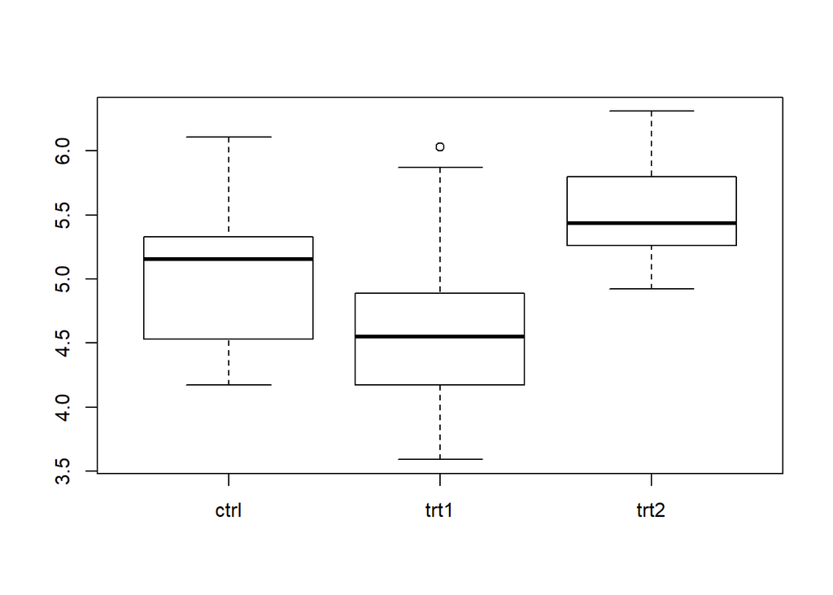

```r
boxplot(weight ~ group, data=PlantGrowth)
```

The box plots summarize the distribution of the data for each of the three groups. It appears that treatment 2 has the highest mean yield. It might be questionable whether each group has the same variance, but we’ll assume that is the case.

#### Modeling

Again, we can start with the reference analysis (with a noninformative prior) with a linear model in R.

```r
lmod = lm(weight ~ group, data=PlantGrowth)
summary(lmod)
```

```
##
## Call:
## lm(formula = weight ~ group, data = PlantGrowth)
##
## Residuals:
##     Min      1Q  Median      3Q     Max
## -1.0710 -0.4180 -0.0060  0.2627  1.3690
##
## Coefficients:
##             Estimate Std. Error t value Pr(>|t|)
## (Intercept)   5.0320     0.1971  25.527   <2e-16 ***
## grouptrt1    -0.3710     0.2788  -1.331   0.1944
## grouptrt2     0.4940     0.2788   1.772   0.0877 .
## ---
## Signif. codes:  0 '***' 0.001 '**' 0.01 '*' 0.05 '.' 0.1 ' ' 1
##
## Residual standard error: 0.6234 on 27 degrees of freedom
## Multiple R-squared:  0.2641, Adjusted R-squared:  0.2096
## F-statistic: 4.846 on 2 and 27 DF,  p-value: 0.01591
```

Pour rappel, les résultats qu’on obtient sont les posterior mean estimates dans “estimate” On lance le modèle linéaire et on fait un summary le premier groupe est l’intercept est le contrôle groupe c’est le mean yield pr le controle groupe les deux autres groupres, donnent la modification par rapport au groupe de contrôle intercept

on voit que la moyenne est à -0.3710, donc ca fait une moyenne de 4.6 entre le controle et le groupe 2 et pour groupe 2, 5.5

```r
anova(lmod)
```

```
## Analysis of Variance Table
##
## Response: weight
##           Df  Sum Sq Mean Sq F value  Pr(>F)
## group      2  3.7663  1.8832  4.8461 0.01591 *
## Residuals 27 10.4921  0.3886
## ---
## Signif. codes:  0 '***' 0.001 '**' 0.01 '*' 0.05 '.' 0.1 ' ' 1
```

on peut calculer la table anova donne le résultat pour chaque factor variable, pr savoir si il contribue fortement a la variabilité des données:

```r
# plot(lmod) # for graphical residual analysis
```

The default model structure in R is the linear model with dummy indicator variables. Hence, the “intercept” in this model is the mean yield for the control group. The two other parameters are the estimated effects of treatments 1 and 2. To recover the mean yield in treatment group 1, you would add the intercept term and the treatment 1 effect. To see how R sets the model up, use the model.matrix(lmod) function to extract the $X$ matrix.

The anova() function in R compares variability of observations between the treatment groups to variability within the treatment groups to test whether all means are equal or whether at least one is different. The small p-value here suggests that the means are not all equal.

Let’s fit the cell means model in JAGS.

```r
library("rjags")
```

avec le modèle jaggs on va utiliser le cell modèle, ou chaque groupe a sa propre mean

```r
mod_string = " model {
# on calcule le likelihood
# la variable grp va nous faire comparer groupe 1 et2 ou 0 et 3 ...
    for (i in 1:length(y)) {
        # on définit un mu pour chaque groupe
        y[i] ~ dnorm(mu[grp[i]], prec)
    }
   # non informative prior
    for (j in 1:3) {
        mu[j] ~ dnorm(0.0, 1.0/1.0e6)
    }
    # pr variance on a gamma, five observation as ou effective sample size
    prec ~ dgamma(5/2.0, 5*1.0/2.0)
    sig = sqrt( 1.0 / prec )
} "

set.seed(82)
str(PlantGrowth)
```

```
## 'data.frame':    30 obs. of  2 variables:
##  $ weight: num  4.17 5.58 5.18 6.11 4.5 4.61 5.17 4.53 5.33 5.14 ...
##  $ group : Factor w/ 3 levels "ctrl","trt1",..: 1 1 1 1 1 1 1 1 1 1 ...
```

```r
# on doit transformer la variable groupe, en numérique (grp)
data_jags = list(y=PlantGrowth$weight,
              grp=as.numeric(PlantGrowth$group))

params = c("mu", "sig")

inits = function() {
    inits = list("mu"=rnorm(3,0.0,100.0), "prec"=rgamma(1,1.0,1.0))
}

mod = jags.model(textConnection(mod_string), data=data_jags, inits=inits, n.chains=3)
# 1e03 iteration burn in
update(mod, 1e3)

mod_sim = coda.samples(model=mod,
                        variable.names=params,
                        n.iter=5e3)
mod_csim = as.mcmc(do.call(rbind, mod_sim)) # combined chains
```

#### Model checking

As usual, we check for convergence of our MCMC.

[figure not shown]

```r
plot(mod_sim)
```

```r
# tres bon resulttat 1
gelman.diag(mod_sim)
```

```
## Potential scale reduction factors:
##
##       Point est. Upper C.I.
## mu[1]          1          1
## mu[2]          1          1
## mu[3]          1          1
## sig            1          1
##
## Multivariate psrf
##
## 1
```

```r
# pas de problem, donc l'effective sample size sera grande proche de la valeur réel de la chaîne
autocorr.diag(mod_sim)
```

```
##               mu[1]         mu[2]        mu[3]           sig
## Lag 0   1.000000000  1.0000000000  1.000000000  1.0000000000
## Lag 1  -0.003516027  0.0197132272 -0.002628334  0.0855695152
## Lag 5  -0.003292298  0.0005666347 -0.010419873 -0.0005042189
## Lag 10  0.007845263  0.0030042459 -0.015439579 -0.0052272171
## Lag 50 -0.009348866 -0.0015468829 -0.001384815  0.0005965723
```

```r
# which is true with effective size
effectiveSize(mod_sim)
```

```
##    mu[1]    mu[2]    mu[3]      sig
## 15000.00 13856.05 14341.81 12633.47
```

We are confident with our 3 indicators We can also look at the residuals to see if there are any obvious problems with our model choice.

```r
(pm_params = colMeans(mod_csim))
```

```
##     mu[1]     mu[2]     mu[3]       sig
## 5.0347366 4.6617541 5.5244822 0.7120801
```

on rgarde les posteriors means, on les compare avec les posteriors coefficient de notre analyse de référence

```r
coefficients(lmod)
```

```
## (Intercept)   grouptrt1   grouptrt2
##       5.032      -0.371       0.494
```

les résultast sont plutôt cohérents, mu1, mu2 et mu3 sont très similaires

```r
# on les indexes par leurs groupes indicators [data_jags$grp], la variable groupe est la version numériques des trois groupes, on rappelle en dessous
yhat = pm_params[1:3][data_jags$grp]
```

```r
data_jags$grp
```

```
##  [1] 1 1 1 1 1 1 1 1 1 1 2 2 2 2 2 2 2 2 2 2 3 3 3 3 3 3 3 3 3 3
```

on affiche aussi y hat, qui nous montre que les mu1 ont bien une valeur de 5.03 comme calculé avant etc

```r
yhat
```

```
##    mu[1]    mu[1]    mu[1]    mu[1]    mu[1]    mu[1]    mu[1]    mu[1]
## 5.034737 5.034737 5.034737 5.034737 5.034737 5.034737 5.034737 5.034737
##    mu[1]    mu[1]    mu[2]    mu[2]    mu[2]    mu[2]    mu[2]    mu[2]
## 5.034737 5.034737 4.661754 4.661754 4.661754 4.661754 4.661754 4.661754
##    mu[2]    mu[2]    mu[2]    mu[2]    mu[3]    mu[3]    mu[3]    mu[3]
## 4.661754 4.661754 4.661754 4.661754 5.524482 5.524482 5.524482 5.524482
##    mu[3]    mu[3]    mu[3]    mu[3]    mu[3]    mu[3]
## 5.524482 5.524482 5.524482 5.524482 5.524482 5.524482
```

on regarde les residuals, on ne voit qu’il n’y a aucun pattern donc c’est bon

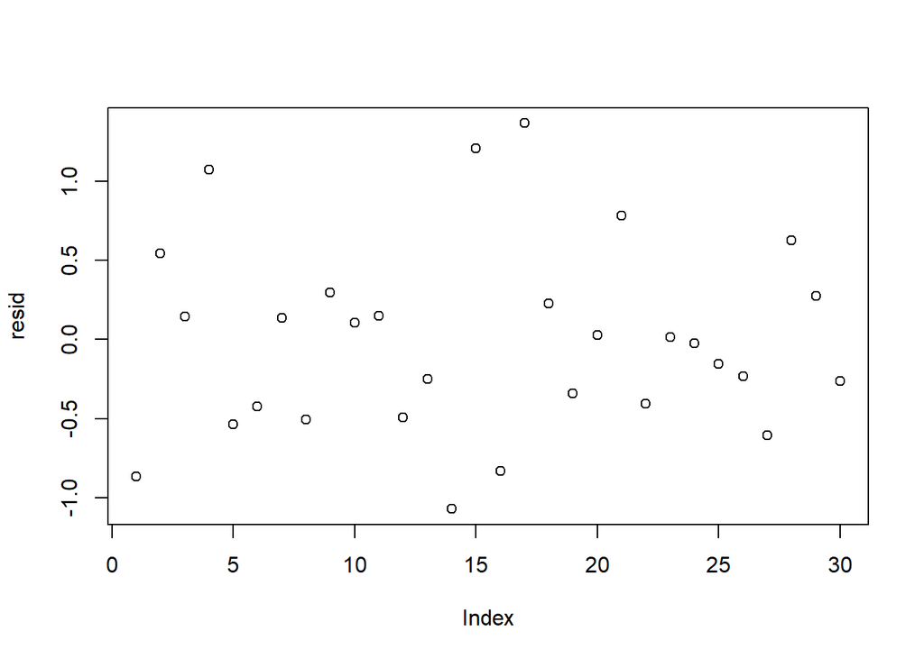

```r
resid = data_jags$y - yhat
plot(resid)
```

on voit qu’il y’a trois sets de variables ce qui est logique avec nos trois facteurs après ce qui ressort fortmeent est que la variance du groupe à gauche, la résidual variance est bien plus forte que celle du groupe 3

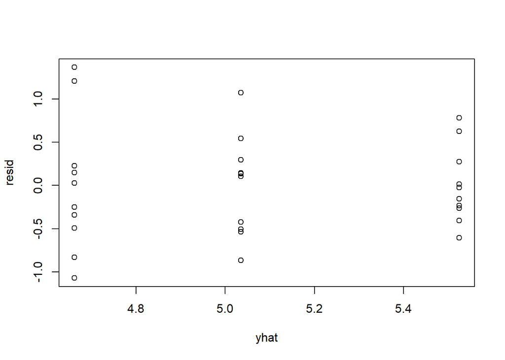

```r
plot(yhat, resid)
```

Again, it might be appropriate to have a separate variance for each group. We will have you do that as an exercise.

#### Results

Let’s look at the posterior summary of the parameters. on peut se demander quel est le 95% interval.

cest compris entre 2.5% et 97.5% donc [4.59;5.49] pour le groupe 1

```r
summary(mod_sim)
```

```
##
## Iterations = 1001:6000
## Thinning interval = 1
## Number of chains = 3
## Sample size per chain = 5000
##
## 1. Empirical mean and standard deviation for each variable,
##    plus standard error of the mean:
##
##         Mean      SD  Naive SE Time-series SE
## mu[1] 5.0347 0.22830 0.0018641      0.0018640
## mu[2] 4.6618 0.22528 0.0018394      0.0019170
## mu[3] 5.5245 0.22538 0.0018402      0.0018849
## sig   0.7121 0.09214 0.0007523      0.0008197
##
## 2. Quantiles for each variable:
##
##         2.5%    25%   50%    75%  97.5%
## mu[1] 4.5808 4.8847 5.033 5.1872 5.4817
## mu[2] 4.2154 4.5114 4.660 4.8117 5.1053
## mu[3] 5.0830 5.3763 5.523 5.6726 5.9697
## sig   0.5597 0.6479 0.703 0.7659 0.9225
```

```r
HPDinterval(mod_csim)
```

```
##           lower     upper
## mu[1] 4.5744861 5.4727442
## mu[2] 4.2228573 5.1099512
## mu[3] 5.0767440 5.9633871
## sig   0.5484689 0.9015995
## attr(,"Probability")
## [1] 0.95
```

on peut aussi changer et se demander quel est le 90% posterior probability intervals

```r
HPDinterval(mod_csim, 0.9)
```

```
##           lower     upper
## mu[1] 4.6797139 5.4304343
## mu[2] 4.2936064 5.0303315
## mu[3] 5.1424953 5.8793582
## sig   0.5636284 0.8537028
## attr(,"Probability")
## [1] 0.9
```

quizzz

```r
mu1 <- HPDinterval(mod_csim[,1], 0.95)
mu3 <- HPDinterval(mod_csim[,3], 0.95)

mu3 - mu1
```

```
##          lower     upper
## var1 0.5022579 0.4906429
## attr(,"Probability")
## [1] 0.95
```

[output not shown]

[output not shown]

```r
print(mod_csim[c("mu[1]")])
```

```
## [1] NA
```

```r
#HPDinterval(mod_csim[1], 0.9)
```

Quizz 2

The HPDinterval() function in the coda package calculates intervals of highest posterior density for each parameter.

We are interested to know if one of the treatments increases mean yield. It is clear that treatment 1 does not. What about treatment 2?

One of the advantage of bayesian, is that it is easy to calculate posterior probabilities of hypothesis like this, is groupe 2 better than control group ?

```r
# le average gives the posterior probability
mean(mod_csim[,3] > mod_csim[,1])
```

```
## [1] 0.9394
```

There is a high posterior probability that the mean yield for treatment 2 is greater than the mean yield for the control group.

It may be the case that treatment 2 would be costly to put into production. Suppose that to be worthwhile, this treatment must increase mean yield by 10%. What is the posterior probability that the increase is at least that?

```r
mean(mod_csim[,3] > 1.1*mod_csim[,1])
```

```
## [1] 0.4837333
```

We have about 50/50 odds that adopting treatment 2 would increase mean yield by at least 10%.

## Quizz

```r
mod_string = " model {
# on calcule le likelihood
# la variable grp va nous faire comparer groupe 1 et2 ou 0 et 3 ...
    for (i in 1:length(y)) {
        y[i] ~ dnorm(mu[grp[i]], prec[grp[i]])
    }
   # non informative prior
    for (j in 1:3) {
        mu[j] ~ dnorm(0.0, 1.0/1.0e6)
    }
    # pr variance on a gamma, five observation as ou effective sample size
    for (j in 1:3){
    prec[j] ~ dgamma(5/2.0, 5*1.0/2.0)
    }
    sig = sqrt( 1.0 / prec )
} "

data("PlantGrowth")
set.seed(82)

# on doit transformer la variable groupe, en numérique (grp)
data_jags = list(y=PlantGrowth$weight,
              grp=as.numeric(PlantGrowth$group))

params = c("mu", "sig")

inits = function() {
    inits = list("mu"=rnorm(3,0.0,100.0), "prec"=rgamma(3,1.0,1.0))
}

mod_quizz = jags.model(textConnection(mod_string), data=data_jags, inits=inits, n.chains=3)
# 1e03 iteration burn in
update(mod, 1e3)

mod_sim_quizz = coda.samples(model=mod_quizz,
                        variable.names=params,
                        n.iter=5e3)
mod_csim_quizz = as.mcmc(do.call(rbind, mod_sim_quizz)) # combined chains

summary(mod_sim_quizz)
```

```
##
## Iterations = 1:5000
## Thinning interval = 1
## Number of chains = 3
## Sample size per chain = 5000
##
## 1. Empirical mean and standard deviation for each variable,
##    plus standard error of the mean:
##
##          Mean     SD Naive SE Time-series SE
## mu[1]  5.0337 0.2592 0.002116       0.002116
## mu[2]  4.6611 0.2958 0.002415       0.002358
## mu[3]  5.5236 0.2377 0.001941       0.001902
## sig[1] 0.8013 0.1650 0.001347       0.001463
## sig[2] 0.9223 0.1910 0.001559       0.001689
## sig[3] 0.7349 0.1514 0.001236       0.001342
##
## 2. Quantiles for each variable:
##
##          2.5%    25%    50%    75% 97.5%
## mu[1]  4.5190 4.8674 5.0329 5.1988 5.558
## mu[2]  4.0721 4.4716 4.6617 4.8505 5.242
## mu[3]  5.0546 5.3711 5.5233 5.6745 5.994
## sig[1] 0.5543 0.6845 0.7757 0.8892 1.196
## sig[2] 0.6424 0.7877 0.8899 1.0220 1.380
## sig[3] 0.5091 0.6290 0.7112 0.8148 1.097
```

on compare leurs DIC

```r
# we added oil for this model
dic2 <- dic.samples(mod_quizz, n.iter=1e5)
```

```r
# we added oil for this model
dic1 <- dic.samples(mod, n.iter=1e5)
```

```r
# we added oil for this model
dic1-dic2
```

```
## Difference: -3.869212
## Sample standard error: 1.648598
```

on nous demande de calculer sur les anciennes données

```r
HPDinterval(mod_csim, 0.9)
```

```
##           lower     upper
## mu[1] 4.6797139 5.4304343
## mu[2] 4.2936064 5.0303315
## mu[3] 5.1424953 5.8793582
## sig   0.5636284 0.8537028
## attr(,"Probability")
## [1] 0.9
```

Bonus - quizzz multi ANOVA

```r
data("warpbreaks")

mod3_string = " model {
    for( i in 1:length(y)) {
        y[i] ~ dnorm(mu[woolGrp[i], tensGrp[i]], prec[woolGrp[i], tensGrp[i]])
    }

    for (j in 1:max(woolGrp)) {
        for (k in 1:max(tensGrp)) {
            mu[j,k] ~ dnorm(0.0, 1.0/1.0e6)
        }
    }
    for (j in 1:max(woolGrp)) {
        for (k in 1:max(tensGrp)) {
    prec[j,k] ~ dgamma(1/2, 1/2)
        }
    }
    sig = sqrt(1.0 / prec)
} "

str(warpbreaks)
```

```
## 'data.frame':    54 obs. of  3 variables:
##  $ breaks : num  26 30 54 25 70 52 51 26 67 18 ...
##  $ wool   : Factor w/ 2 levels "A","B": 1 1 1 1 1 1 1 1 1 1 ...
##  $ tension: Factor w/ 3 levels "L","M","H": 1 1 1 1 1 1 1 1 1 2 ...
```

```r
data3_jags = list(y=log(warpbreaks$breaks), woolGrp=as.numeric(warpbreaks$wool), tensGrp=as.numeric(warpbreaks$tension))

params3 = c("mu", "sig")

mod3 = jags.model(textConnection(mod3_string), data=data3_jags, n.chains=3)
```

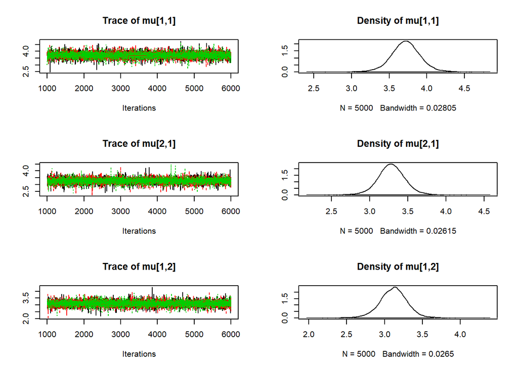

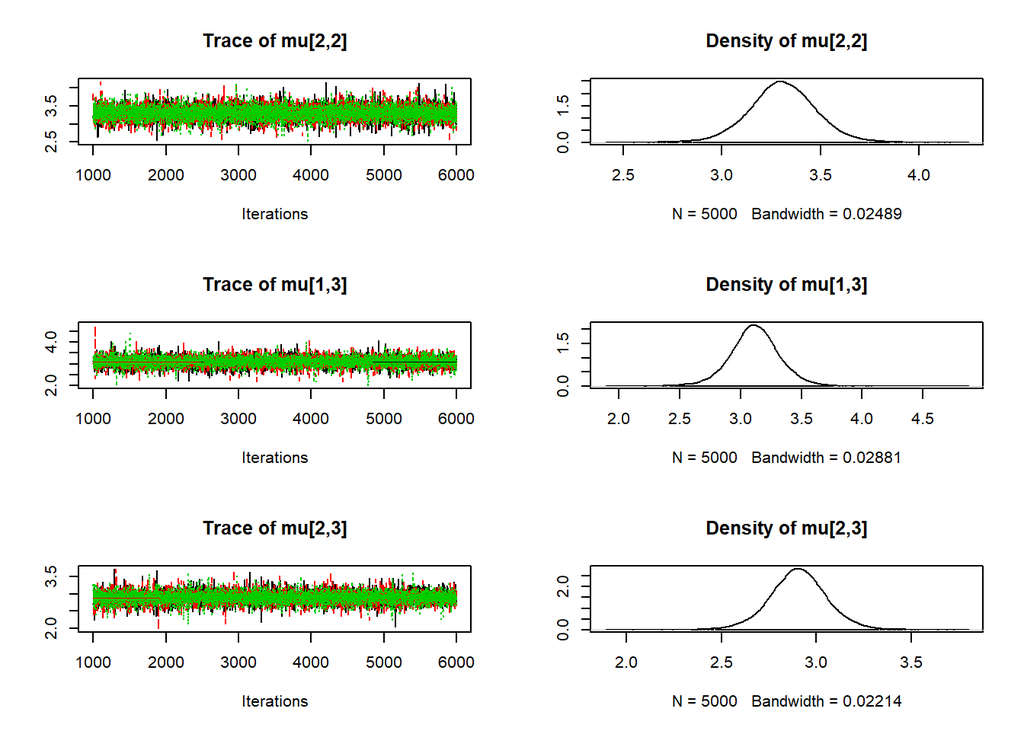

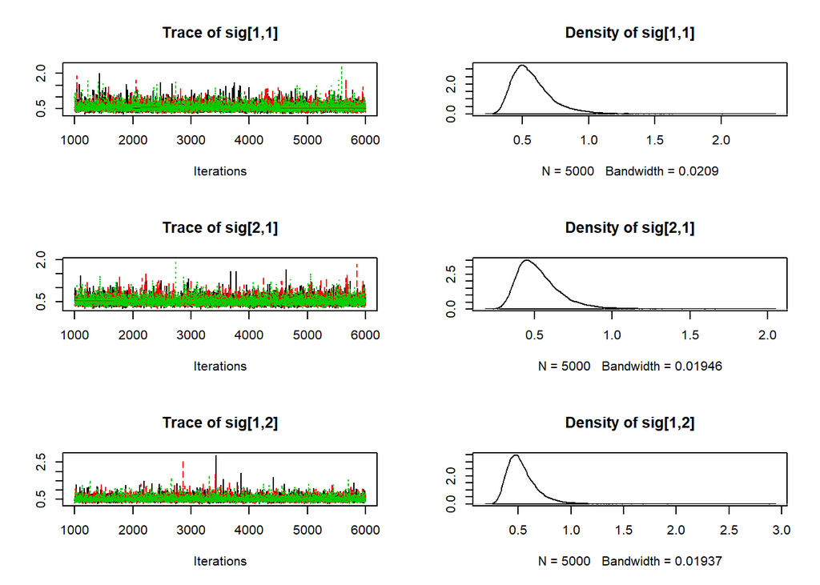

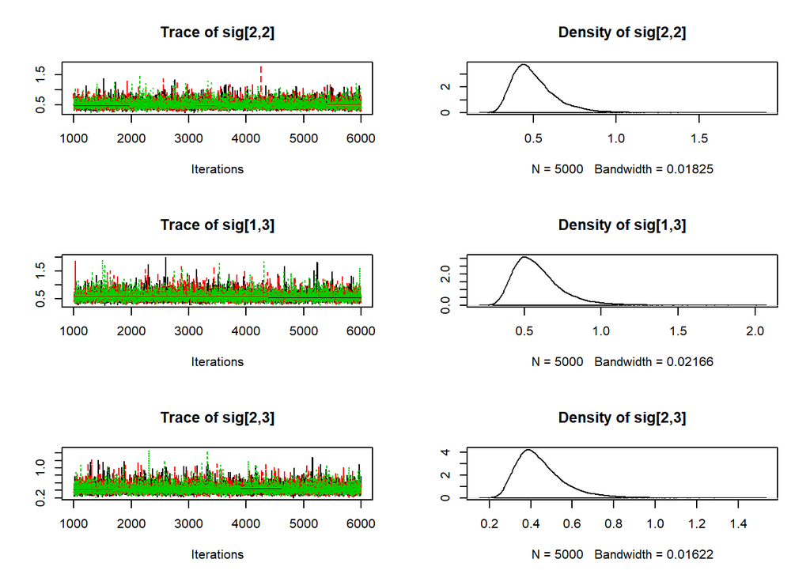

```r
update(mod3, 1e3)

mod3_sim = coda.samples(model=mod3,
                        variable.names=params3,
                        n.iter=5e3)
mod3_csim = as.mcmc(do.call(rbind, mod3_sim))

plot(mod3_sim, ask=TRUE)
```

```r
## convergence diagnostics
gelman.diag(mod3_sim)
```

```
## Potential scale reduction factors:
##
##          Point est. Upper C.I.
## mu[1,1]           1       1.00
## mu[2,1]           1       1.00
## mu[1,2]           1       1.00
## mu[2,2]           1       1.00
## mu[1,3]           1       1.00
## mu[2,3]           1       1.00
## sig[1,1]          1       1.00
## sig[2,1]          1       1.01
## sig[1,2]          1       1.00
## sig[2,2]          1       1.00
## sig[1,3]          1       1.00
## sig[2,3]          1       1.00
##
## Multivariate psrf
##
## 1
```

```r
autocorr.diag(mod3_sim)
```

```
##             mu[1,1]      mu[2,1]      mu[1,2]      mu[2,2]      mu[1,3]
## Lag 0   1.000000000  1.000000000  1.000000000  1.000000000  1.000000000
## Lag 1   0.001989505  0.006995334 -0.007829009 -0.013621483  0.018153489
## Lag 5  -0.012662730 -0.002560845  0.006161710  0.002461039 -0.008847797
## Lag 10 -0.013744032 -0.001263269  0.005454540  0.002000836 -0.001136970
## Lag 50  0.014140333  0.004895890  0.003093725  0.002965555 -0.002621928
##             mu[2,3]      sig[1,1]    sig[2,1]     sig[1,2]     sig[2,2]
## Lag 0   1.000000000  1.000000e+00 1.000000000  1.000000000  1.000000000
## Lag 1   0.007563674  1.168936e-01 0.129022027  0.112769412  0.119976453
## Lag 5  -0.003657519  1.761921e-03 0.007212556 -0.006813022 -0.005072381
## Lag 10  0.013311314  8.417315e-06 0.006338244 -0.002953792  0.013021195
## Lag 50  0.014970922 -3.635739e-03 0.002984770  0.013658799 -0.003932922
##            sig[1,3]      sig[2,3]
## Lag 0   1.000000000  1.0000000000
## Lag 1   0.130624152  0.1438670289
## Lag 5  -0.013358257 -0.0150334865
## Lag 10  0.006621924 -0.0008553531
## Lag 50 -0.009183507  0.0036745321
```

```r
effectiveSize(mod3_sim)
```

```
##  mu[1,1]  mu[2,1]  mu[1,2]  mu[2,2]  mu[1,3]  mu[2,3] sig[1,1] sig[2,1]
## 14739.57 14724.39 15542.89 15395.23 14277.13 14928.16 11460.29 11571.71
## sig[1,2] sig[2,2] sig[1,3] sig[2,3]
## 11839.02 11593.41 11190.33 11438.38
```

```r
raftery.diag(mod3_sim)
```

```
## [[1]]
##
## Quantile (q) = 0.025
## Accuracy (r) = +/- 0.005
## Probability (s) = 0.95
##
##           Burn-in  Total Lower bound  Dependence
##           (M)      (N)   (Nmin)       factor (I)
##  mu[1,1]  3        4410  3746         1.180
##  mu[2,1]  3        4267  3746         1.140
##  mu[1,2]  3        4198  3746         1.120
##  mu[2,2]  2        3995  3746         1.070
##  mu[1,3]  2        3803  3746         1.020
##  mu[2,3]  3        4062  3746         1.080
##  sig[1,1] 2        3803  3746         1.020
##  sig[2,1] 2        3995  3746         1.070
##  sig[1,2] 2        3594  3746         0.959
##  sig[2,2] 2        3803  3746         1.020
##  sig[1,3] 2        3803  3746         1.020
##  sig[2,3] 2        3680  3746         0.982
##
##
## [[2]]
##
## Quantile (q) = 0.025
## Accuracy (r) = +/- 0.005
## Probability (s) = 0.95
##
##           Burn-in  Total Lower bound  Dependence
##           (M)      (N)   (Nmin)       factor (I)
##  mu[1,1]  2        3741  3746         0.999
##  mu[2,1]  2        3930  3746         1.050
##  mu[1,2]  2        3803  3746         1.020
##  mu[2,2]  3        4410  3746         1.180
##  mu[1,3]  3        4062  3746         1.080
##  mu[2,3]  3        4129  3746         1.100
##  sig[1,1] 2        3680  3746         0.982
##  sig[2,1] 2        3741  3746         0.999
##  sig[1,2] 2        3741  3746         0.999
##  sig[2,2] 2        3866  3746         1.030
```

[output cut: 9 more lines]

```
##
##           Burn-in  Total Lower bound  Dependence
##           (M)      (N)   (Nmin)       factor (I)
##  mu[1,1]  2        3964  3746         1.060
##  mu[2,1]  2        3930  3746         1.050
##  mu[1,2]  2        3995  3746         1.070
##  mu[2,2]  3        4062  3746         1.080
##  mu[1,3]  4        4636  3746         1.240
##  mu[2,3]  2        3995  3746         1.070
##  sig[1,1] 2        3930  3746         1.050
##  sig[2,1] 2        3803  3746         1.020
##  sig[1,2] 2        3803  3746         1.020
##  sig[2,2] 2        3680  3746         0.982
##  sig[1,3] 2        3561  3746         0.951
##  sig[2,3] 2        3741  3746         0.999
```

```r
dic2 <- dic.samples(mod3, n.iter=1e5)
```